```python
import seaborn as sns
import matplotlib as mpl

import matplotlib.pyplot as plt
import numpy as np
import os
from datetime import datetime
import pandas as pd
mpl.rcParams['figure.figsize']=(10,8)
mpl.rcParams["axes.grid"]=False
```

```python
def parse(x):
    return datetime.strptime(x,"%m/%d/%Y")
```

# ASSUMPTION OF MOVING AVERAGE :

1. Time series is stationary
2. it has a very slow varying mean or constant mean ............... if your Data lot of fluctuations & if your data non-stationary mean then may be MA might be the not best model for forecasting

Here my data aset is not stationary , just show you various moving averages react to it . beacuse if i take a stationary data , then all the moving average might look similar . so i'm goinng to take non stationary data, and showing you how it's perfom non stationary data.

```python
df=pd.read_csv('https://raw.githubusercontent.com/srivatsan88/YoutubeLI/master/dataset/electricity_consumption.csv',parse_dates=['Bill_Date'],date_parser=parse)
df.head()
```

|  | Bill_Date | On_peak | Off_peak | Usage_charge | Billed_amount | Billing_days |
| --- | --- | --- | --- | --- | --- | --- |
| 0 | 2016-01-01 | 365 | 1423.5 | 219.0 | 247.73 | 31 |
| 1 | 2016-02-01 | 292 | 1138.8 | 175.2 | 234.11 | 31 |
| 2 | 2016-03-01 | 130 | 507.0 | 78.0 | 123.85 | 29 |
| 3 | 2016-04-01 | 117 | 456.3 | 70.2 | 111.22 | 29 |
| 4 | 2016-05-01 | 136 | 530.4 | 81.6 | 118.37 | 29 |

Now this data set as a build date column which i said like it's a date time column , and the data is ordered by bill date . and i have bill amount column which i'm going to used for this analysis this is only column i'm going to used . but there are other column as well, this 'on_peak' and "off_peak" is basically the kilowatts that i am using every month . so the way my bill is basically i have an on_peak charge and off_peak charge if i put my area appliances doing the off_peak then i'm paying very less on my electricity bill but if i use the suppliers on my on_peak i am atleast paying 3 times the regular electricity charge.

Visualize this data set

```python
print("Rows        : ",df.shape[0])
print("Columns     : ",df.shape[1])
print("\nFeatures  : ",df.columns.tolist())
print("\nMissing values : ",df.isnull().any())
print("\n Unique value  : ",df.nunique())
```

```
Rows        :  53
Columns     :  6

Features  :  ['Bill_Date', 'On_peak', 'Off_peak', 'Usage_charge', 'Billed_amount', 'Billing_days']

Missing values :  Bill_Date        False
On_peak          False
Off_peak         False
Usage_charge     False
Billed_amount    False
Billing_days     False
dtype: bool

 Unique value  :  Bill_Date        53
On_peak          51
Off_peak         53
Usage_charge     53
Billed_amount    52
Billing_days      9
dtype: int64
```

1. There are no missing value

I am taking the data frame , i'm setting bill date as the index column , reasone is lot of plotting function or lot of statistical techniques to analyse time series want this as an index function , 2nd reason is creating it as an index makes my analysis easy. whether if i don't create a syntax i have to do exact string search but with index i can do substring search and i can do partial string search so that's the reason i am doing a set a set index and assigining it to a bill_df

```python
bill_df=df.set_index("Bill_Date")
bill_df.head()
```

| Bill_Date | On_peak | Off_peak | Usage_charge | Billed_amount | Billing_days |
| --- | --- | --- | --- | --- | --- |
| 2016-01-01 | 365 | 1423.5 | 219.0 | 247.73 | 31 |
| 2016-02-01 | 292 | 1138.8 | 175.2 | 234.11 | 31 |
| 2016-03-01 | 130 | 507.0 | 78.0 | 123.85 | 29 |
| 2016-04-01 | 117 | 456.3 | 70.2 | 111.22 | 29 |
| 2016-05-01 | 136 | 530.4 | 81.6 | 118.37 | 29 |

Now i'm just taking bill_amount column and i'm taking between year 2016 to 2018

```python
bill_2018=bill_df['2016':'2018'][['Billed_amount']]
bill_2018
```

| Bill_Date | Billed_amount |
| --- | --- |
| 2016-01-01 | 247.73 |
| 2016-02-01 | 234.11 |
| 2016-03-01 | 123.85 |
| 2016-04-01 | 111.22 |
| 2016-05-01 | 118.37 |
| 2016-06-01 | 77.81 |
| 2016-07-01 | 86.67 |
| 2016-08-01 | 122.40 |
| 2016-09-01 | 223.62 |
| 2016-10-01 | 152.54 |
| 2016-11-01 | 150.54 |
| 2016-12-01 | 244.37 |
| 2017-01-01 | 263.64 |
| 2017-02-01 | 214.32 |
| 2017-03-01 | 151.54 |
| 2017-04-01 | 118.79 |
| 2017-05-01 | 153.18 |
| 2017-06-01 | 212.08 |
| 2017-07-01 | 281.19 |
| 2017-08-01 | 237.97 |
| 2017-09-01 | 284.30 |
| 2017-10-01 | 172.69 |
| 2017-11-01 | 111.51 |
| 2017-12-01 | 151.42 |
| 2018-01-01 | 267.32 |
| 2018-02-01 | 201.35 |
| 2018-03-01 | 202.91 |
| 2018-04-01 | 150.86 |
| 2018-05-01 | 163.07 |
| 2018-06-01 | 219.76 |
| 2018-07-01 | 283.98 |
| 2018-08-01 | 290.15 |
| 2018-09-01 | 257.96 |
| 2018-10-01 | 327.19 |
| 2018-11-01 | 193.49 |
| 2018-12-01 | 152.34 |

# Simple Moving Average

Simple Moving Average =(t+(t-1)+(t-2)+...+(t-n))/n

here i'm takking n=3 . i.e, window=3

```python
bill_2018['Billed_amount'].rolling(window=3).mean()
```

```
Bill_Date
2016-01-01           NaN
2016-02-01           NaN
2016-03-01    201.896667
2016-04-01    156.393333
2016-05-01    117.813333
2016-06-01    102.466667
2016-07-01     94.283333
2016-08-01     95.626667
2016-09-01    144.230000
2016-10-01    166.186667
2016-11-01    175.566667
2016-12-01    182.483333
2017-01-01    219.516667
2017-02-01    240.776667
2017-03-01    209.833333
2017-04-01    161.550000
2017-05-01    141.170000
2017-06-01    161.350000
2017-07-01    215.483333
2017-08-01    243.746667
2017-09-01    267.820000
2017-10-01    231.653333
2017-11-01    189.500000
2017-12-01    145.206667
2018-01-01    176.750000
2018-02-01    206.696667
2018-03-01    223.860000
2018-04-01    185.040000
2018-05-01    172.280000
2018-06-01    177.896667
2018-07-01    222.270000
2018-08-01    264.630000
2018-09-01    277.363333
2018-10-01    291.766667
2018-11-01    259.546667
2018-12-01    224.340000
Name: Billed_amount, dtype: float64
```

```python
bill_2018["MA_rolling_3"]=bill_2018['Billed_amount'].rolling(window=3).mean().shift(1)
bill_2018
# The reason i'm using shift(1) function is basically i'm taking current value and previous two value and i'm predicting
# next value
```

| Bill_Date | Billed_amount | MA_rolling_3 |
| --- | --- | --- |
| 2016-01-01 | 247.73 | NaN |
| 2016-02-01 | 234.11 | NaN |
| 2016-03-01 | 123.85 | NaN |
| 2016-04-01 | 111.22 | 201.896667 |
| 2016-05-01 | 118.37 | 156.393333 |
| 2016-06-01 | 77.81 | 117.813333 |
| 2016-07-01 | 86.67 | 102.466667 |
| 2016-08-01 | 122.40 | 94.283333 |
| 2016-09-01 | 223.62 | 95.626667 |
| 2016-10-01 | 152.54 | 144.230000 |
| 2016-11-01 | 150.54 | 166.186667 |
| 2016-12-01 | 244.37 | 175.566667 |
| 2017-01-01 | 263.64 | 182.483333 |
| 2017-02-01 | 214.32 | 219.516667 |
| 2017-03-01 | 151.54 | 240.776667 |
| 2017-04-01 | 118.79 | 209.833333 |
| 2017-05-01 | 153.18 | 161.550000 |
| 2017-06-01 | 212.08 | 141.170000 |
| 2017-07-01 | 281.19 | 161.350000 |
| 2017-08-01 | 237.97 | 215.483333 |
| 2017-09-01 | 284.30 | 243.746667 |
| 2017-10-01 | 172.69 | 267.820000 |
| 2017-11-01 | 111.51 | 231.653333 |
| 2017-12-01 | 151.42 | 189.500000 |
| 2018-01-01 | 267.32 | 145.206667 |
| 2018-02-01 | 201.35 | 176.750000 |
| 2018-03-01 | 202.91 | 206.696667 |
| 2018-04-01 | 150.86 | 223.860000 |
| 2018-05-01 | 163.07 | 185.040000 |
| 2018-06-01 | 219.76 | 172.280000 |
| 2018-07-01 | 283.98 | 177.896667 |
| 2018-08-01 | 290.15 | 222.270000 |
| 2018-09-01 | 257.96 | 264.630000 |
| 2018-10-01 | 327.19 | 277.363333 |
| 2018-11-01 | 193.49 | 291.766667 |
| 2018-12-01 | 152.34 | 259.546667 |

Here MA_rolling and MA_rolling_3 both are same column

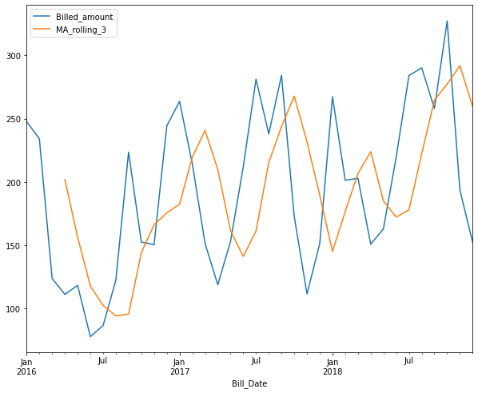

```python
bill_2018.plot()
```

Just see the output it's not like closer blue and orange line

# Weighted Moving Average

Weighted Moving Average=(t*weighting factor)+((t-1)*weighting factor-1)+...+((t-n)*weighting factor-n)/n

```python
def w_MA(weights):
    def calc(x):
        return (weights*x).mean()
    return calc
```

```python
bill_2018["Billed_amount"].rolling(window=3).apply(w_MA(np.array([0.5,1,1.5])))
```

```
Bill_Date
2016-01-01           NaN
2016-02-01           NaN
2016-03-01    181.250000
2016-04-01    135.911667
2016-05-01    116.900000
2016-06-01     96.898333
2016-07-01     89.000000
2016-08-01    103.058333
2016-09-01    167.055000
2016-10-01    171.210000
2016-11-01    163.386667
2016-12-01    197.788333
2017-01-01    238.366667
2017-02-01    235.768333
2017-03-01    191.150000
2017-04-01    145.628333
2017-05-01    141.443333
2017-06-01    176.898333
2017-07-01    236.818333
2017-08-01    248.061667
2017-09-01    268.338333
2017-10-01    220.773333
2017-11-01    160.701667
2017-12-01    141.661667
2018-01-01    202.718333
2018-02-01    215.018333
2018-03-01    213.125000
2018-04-01    176.625000
2018-05-01    165.640000
2018-06-01    189.380000
2018-07-01    242.421667
2018-08-01    276.361667
2018-09-01    273.026667
2018-10-01    297.940000
2018-11-01    248.801667
2018-12-01    195.198333
Name: Billed_amount, dtype: float64
```

```python
bill_2018["W_MA_rolling_3"]=bill_2018['Billed_amount'].rolling(window=3).apply(w_MA(np.array([0.5,1,1.5]))).shift(1)
bill_2018
```

| Bill_Date | Billed_amount | MA_rolling_3 | W_MA_rolling_3 |
| --- | --- | --- | --- |
| 2016-01-01 | 247.73 | NaN | NaN |
| 2016-02-01 | 234.11 | NaN | NaN |
| 2016-03-01 | 123.85 | NaN | NaN |
| 2016-04-01 | 111.22 | 201.896667 | 181.250000 |
| 2016-05-01 | 118.37 | 156.393333 | 135.911667 |
| 2016-06-01 | 77.81 | 117.813333 | 116.900000 |
| 2016-07-01 | 86.67 | 102.466667 | 96.898333 |
| 2016-08-01 | 122.40 | 94.283333 | 89.000000 |
| 2016-09-01 | 223.62 | 95.626667 | 103.058333 |
| 2016-10-01 | 152.54 | 144.230000 | 167.055000 |
| 2016-11-01 | 150.54 | 166.186667 | 171.210000 |
| 2016-12-01 | 244.37 | 175.566667 | 163.386667 |
| 2017-01-01 | 263.64 | 182.483333 | 197.788333 |
| 2017-02-01 | 214.32 | 219.516667 | 238.366667 |
| 2017-03-01 | 151.54 | 240.776667 | 235.768333 |
| 2017-04-01 | 118.79 | 209.833333 | 191.150000 |
| 2017-05-01 | 153.18 | 161.550000 | 145.628333 |
| 2017-06-01 | 212.08 | 141.170000 | 141.443333 |
| 2017-07-01 | 281.19 | 161.350000 | 176.898333 |
| 2017-08-01 | 237.97 | 215.483333 | 236.818333 |
| 2017-09-01 | 284.30 | 243.746667 | 248.061667 |
| 2017-10-01 | 172.69 | 267.820000 | 268.338333 |
| 2017-11-01 | 111.51 | 231.653333 | 220.773333 |
| 2017-12-01 | 151.42 | 189.500000 | 160.701667 |
| 2018-01-01 | 267.32 | 145.206667 | 141.661667 |
| 2018-02-01 | 201.35 | 176.750000 | 202.718333 |
| 2018-03-01 | 202.91 | 206.696667 | 215.018333 |
| 2018-04-01 | 150.86 | 223.860000 | 213.125000 |
| 2018-05-01 | 163.07 | 185.040000 | 176.625000 |
| 2018-06-01 | 219.76 | 172.280000 | 165.640000 |
| 2018-07-01 | 283.98 | 177.896667 | 189.380000 |
| 2018-08-01 | 290.15 | 222.270000 | 242.421667 |
| 2018-09-01 | 257.96 | 264.630000 | 276.361667 |
| 2018-10-01 | 327.19 | 277.363333 | 273.026667 |
| 2018-11-01 | 193.49 | 291.766667 | 297.940000 |
| 2018-12-01 | 152.34 | 259.546667 | 248.801667 |

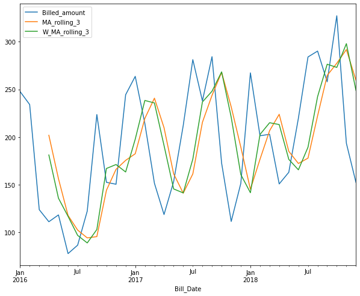

```python
bill_2018.plot()
```

# Exponential Moving Average

Exponential Moving average =(close -previous EMA)*(2/(span+1))+previous EMA

```python
bill_2018['Billed_amount'].ewm(span=3,adjust=False,min_periods=0).mean()
```

```
Bill_Date
2016-01-01    247.730000
2016-02-01    240.920000
2016-03-01    182.385000
2016-04-01    146.802500
2016-05-01    132.586250
2016-06-01    105.198125
2016-07-01     95.934063
2016-08-01    109.167031
2016-09-01    166.393516
2016-10-01    159.466758
2016-11-01    155.003379
2016-12-01    199.686689
2017-01-01    231.663345
2017-02-01    222.991672
2017-03-01    187.265836
2017-04-01    153.027918
2017-05-01    153.103959
2017-06-01    182.591980
2017-07-01    231.890990
2017-08-01    234.930495
2017-09-01    259.615247
2017-10-01    216.152624
2017-11-01    163.831312
2017-12-01    157.625656
2018-01-01    212.472828
2018-02-01    206.911414
2018-03-01    204.910707
2018-04-01    177.885353
2018-05-01    170.477677
2018-06-01    195.118838
2018-07-01    239.549419
2018-08-01    264.849710
2018-09-01    261.404855
2018-10-01    294.297427
2018-11-01    243.893714
2018-12-01    198.116857
Name: Billed_amount, dtype: float64
```

```python
bill_2018["EMA_window_3"]=bill_2018['Billed_amount'].ewm(span=3,adjust=False,min_periods=0).mean().shift(1)
bill_2018
```

| Bill_Date | Billed_amount | MA_rolling_3 | W_MA_rolling_3 | EMA_window_3 |
| --- | --- | --- | --- | --- |
| 2016-01-01 | 247.73 | NaN | NaN | NaN |
| 2016-02-01 | 234.11 | NaN | NaN | 247.730000 |
| 2016-03-01 | 123.85 | NaN | NaN | 240.920000 |
| 2016-04-01 | 111.22 | 201.896667 | 181.250000 | 182.385000 |
| 2016-05-01 | 118.37 | 156.393333 | 135.911667 | 146.802500 |
| 2016-06-01 | 77.81 | 117.813333 | 116.900000 | 132.586250 |
| 2016-07-01 | 86.67 | 102.466667 | 96.898333 | 105.198125 |
| 2016-08-01 | 122.40 | 94.283333 | 89.000000 | 95.934063 |
| 2016-09-01 | 223.62 | 95.626667 | 103.058333 | 109.167031 |
| 2016-10-01 | 152.54 | 144.230000 | 167.055000 | 166.393516 |
| 2016-11-01 | 150.54 | 166.186667 | 171.210000 | 159.466758 |
| 2016-12-01 | 244.37 | 175.566667 | 163.386667 | 155.003379 |
| 2017-01-01 | 263.64 | 182.483333 | 197.788333 | 199.686689 |
| 2017-02-01 | 214.32 | 219.516667 | 238.366667 | 231.663345 |
| 2017-03-01 | 151.54 | 240.776667 | 235.768333 | 222.991672 |
| 2017-04-01 | 118.79 | 209.833333 | 191.150000 | 187.265836 |
| 2017-05-01 | 153.18 | 161.550000 | 145.628333 | 153.027918 |
| 2017-06-01 | 212.08 | 141.170000 | 141.443333 | 153.103959 |
| 2017-07-01 | 281.19 | 161.350000 | 176.898333 | 182.591980 |
| 2017-08-01 | 237.97 | 215.483333 | 236.818333 | 231.890990 |
| 2017-09-01 | 284.30 | 243.746667 | 248.061667 | 234.930495 |
| 2017-10-01 | 172.69 | 267.820000 | 268.338333 | 259.615247 |
| 2017-11-01 | 111.51 | 231.653333 | 220.773333 | 216.152624 |
| 2017-12-01 | 151.42 | 189.500000 | 160.701667 | 163.831312 |
| 2018-01-01 | 267.32 | 145.206667 | 141.661667 | 157.625656 |
| 2018-02-01 | 201.35 | 176.750000 | 202.718333 | 212.472828 |
| 2018-03-01 | 202.91 | 206.696667 | 215.018333 | 206.911414 |
| 2018-04-01 | 150.86 | 223.860000 | 213.125000 | 204.910707 |
| 2018-05-01 | 163.07 | 185.040000 | 176.625000 | 177.885353 |
| 2018-06-01 | 219.76 | 172.280000 | 165.640000 | 170.477677 |
| 2018-07-01 | 283.98 | 177.896667 | 189.380000 | 195.118838 |
| 2018-08-01 | 290.15 | 222.270000 | 242.421667 | 239.549419 |
| 2018-09-01 | 257.96 | 264.630000 | 276.361667 | 264.849710 |
| 2018-10-01 | 327.19 | 277.363333 | 273.026667 | 261.404855 |
| 2018-11-01 | 193.49 | 291.766667 | 297.940000 | 294.297427 |
| 2018-12-01 | 152.34 | 259.546667 | 248.801667 | 243.893714 |

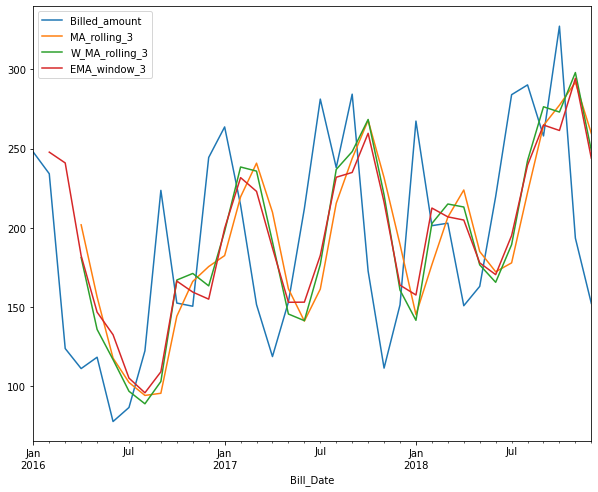

```python
bill_2018.plot()
```

# Exponential Smoothing average

```python
bill_2018["Billed_amount"].ewm(alpha=0.7,adjust=False,min_periods=3).mean()
```

```
Bill_Date
2016-01-01           NaN
2016-02-01           NaN
2016-03-01    158.153800
2016-04-01    125.300140
2016-05-01    120.449042
2016-06-01     90.601713
2016-07-01     87.849514
2016-08-01    112.034854
2016-09-01    190.144456
2016-10-01    163.821337
2016-11-01    154.524401
2016-12-01    217.416320
2017-01-01    249.772896
2017-02-01    224.955869
2017-03-01    173.564761
2017-04-01    135.222428
2017-05-01    147.792728
2017-06-01    192.793819
2017-07-01    254.671146
2017-08-01    242.980344
2017-09-01    271.904103
2017-10-01    202.454231
2017-11-01    138.793269
2017-12-01    147.631981
2018-01-01    231.413594
2018-02-01    210.369078
2018-03-01    205.147723
2018-04-01    167.146317
2018-05-01    164.292895
2018-06-01    203.119869
2018-07-01    259.721961
2018-08-01    281.021588
2018-09-01    264.878476
2018-10-01    308.496543
2018-11-01    227.991963
2018-12-01    175.035589
Name: Billed_amount, dtype: float64
```

```python
bill_2018["ESMA_window_3_7"]=bill_2018['Billed_amount'].ewm(alpha=0.7,adjust=False,min_periods=3).mean().shift(1)
bill_2018
```

| Bill_Date | Billed_amount | MA_rolling_3 | W_MA_rolling_3 | EMA_window_3 | ESMA_window_3_7 |
| --- | --- | --- | --- | --- | --- |
| 2016-01-01 | 247.73 | NaN | NaN | NaN | NaN |
| 2016-02-01 | 234.11 | NaN | NaN | 247.730000 | NaN |
| 2016-03-01 | 123.85 | NaN | NaN | 240.920000 | NaN |
| 2016-04-01 | 111.22 | 201.896667 | 181.250000 | 182.385000 | 158.153800 |
| 2016-05-01 | 118.37 | 156.393333 | 135.911667 | 146.802500 | 125.300140 |
| 2016-06-01 | 77.81 | 117.813333 | 116.900000 | 132.586250 | 120.449042 |
| 2016-07-01 | 86.67 | 102.466667 | 96.898333 | 105.198125 | 90.601713 |
| 2016-08-01 | 122.40 | 94.283333 | 89.000000 | 95.934063 | 87.849514 |
| 2016-09-01 | 223.62 | 95.626667 | 103.058333 | 109.167031 | 112.034854 |
| 2016-10-01 | 152.54 | 144.230000 | 167.055000 | 166.393516 | 190.144456 |
| 2016-11-01 | 150.54 | 166.186667 | 171.210000 | 159.466758 | 163.821337 |
| 2016-12-01 | 244.37 | 175.566667 | 163.386667 | 155.003379 | 154.524401 |
| 2017-01-01 | 263.64 | 182.483333 | 197.788333 | 199.686689 | 217.416320 |
| 2017-02-01 | 214.32 | 219.516667 | 238.366667 | 231.663345 | 249.772896 |
| 2017-03-01 | 151.54 | 240.776667 | 235.768333 | 222.991672 | 224.955869 |
| 2017-04-01 | 118.79 | 209.833333 | 191.150000 | 187.265836 | 173.564761 |
| 2017-05-01 | 153.18 | 161.550000 | 145.628333 | 153.027918 | 135.222428 |
| 2017-06-01 | 212.08 | 141.170000 | 141.443333 | 153.103959 | 147.792728 |
| 2017-07-01 | 281.19 | 161.350000 | 176.898333 | 182.591980 | 192.793819 |
| 2017-08-01 | 237.97 | 215.483333 | 236.818333 | 231.890990 | 254.671146 |
| 2017-09-01 | 284.30 | 243.746667 | 248.061667 | 234.930495 | 242.980344 |
| 2017-10-01 | 172.69 | 267.820000 | 268.338333 | 259.615247 | 271.904103 |
| 2017-11-01 | 111.51 | 231.653333 | 220.773333 | 216.152624 | 202.454231 |
| 2017-12-01 | 151.42 | 189.500000 | 160.701667 | 163.831312 | 138.793269 |
| 2018-01-01 | 267.32 | 145.206667 | 141.661667 | 157.625656 | 147.631981 |
| 2018-02-01 | 201.35 | 176.750000 | 202.718333 | 212.472828 | 231.413594 |
| 2018-03-01 | 202.91 | 206.696667 | 215.018333 | 206.911414 | 210.369078 |
| 2018-04-01 | 150.86 | 223.860000 | 213.125000 | 204.910707 | 205.147723 |
| 2018-05-01 | 163.07 | 185.040000 | 176.625000 | 177.885353 | 167.146317 |
| 2018-06-01 | 219.76 | 172.280000 | 165.640000 | 170.477677 | 164.292895 |
| 2018-07-01 | 283.98 | 177.896667 | 189.380000 | 195.118838 | 203.119869 |
| 2018-08-01 | 290.15 | 222.270000 | 242.421667 | 239.549419 | 259.721961 |
| 2018-09-01 | 257.96 | 264.630000 | 276.361667 | 264.849710 | 281.021588 |
| 2018-10-01 | 327.19 | 277.363333 | 273.026667 | 261.404855 | 264.878476 |
| 2018-11-01 | 193.49 | 291.766667 | 297.940000 | 294.297427 | 308.496543 |
| 2018-12-01 | 152.34 | 259.546667 | 248.801667 | 243.893714 | 227.991963 |

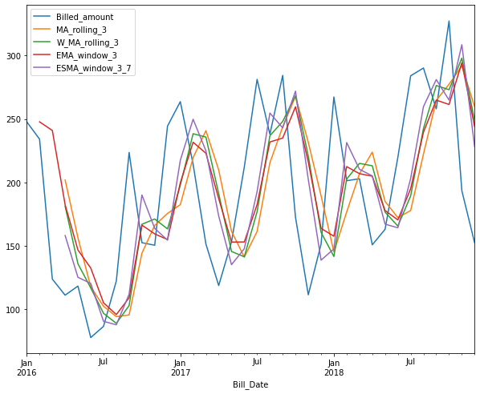

```python
bill_2018.plot()
```

Here u can see exponential moving average capture trend in data, and closely following output

# Doing Exponential smoothing with value 0.3

```python
bill_2018["ESMA_window_3_3"]=bill_2018['Billed_amount'].ewm(alpha=0.3,adjust=False,min_periods=3).mean().shift(1)
bill_2018
```

| Bill_Date | Billed_amount | MA_rolling_3 | W_MA_rolling_3 | EMA_window_3 | ESMA_window_3_7 | ESMA_window_3_3 |
| --- | --- | --- | --- | --- | --- | --- |
| 2016-01-01 | 247.73 | NaN | NaN | NaN | NaN | NaN |
| 2016-02-01 | 234.11 | NaN | NaN | 247.730000 | NaN | NaN |
| 2016-03-01 | 123.85 | NaN | NaN | 240.920000 | NaN | NaN |
| 2016-04-01 | 111.22 | 201.896667 | 181.250000 | 182.385000 | 158.153800 | 207.705800 |
| 2016-05-01 | 118.37 | 156.393333 | 135.911667 | 146.802500 | 125.300140 | 178.760060 |
| 2016-06-01 | 77.81 | 117.813333 | 116.900000 | 132.586250 | 120.449042 | 160.643042 |
| 2016-07-01 | 86.67 | 102.466667 | 96.898333 | 105.198125 | 90.601713 | 135.793129 |
| 2016-08-01 | 122.40 | 94.283333 | 89.000000 | 95.934063 | 87.849514 | 121.056191 |
| 2016-09-01 | 223.62 | 95.626667 | 103.058333 | 109.167031 | 112.034854 | 121.459333 |
| 2016-10-01 | 152.54 | 144.230000 | 167.055000 | 166.393516 | 190.144456 | 152.107533 |
| 2016-11-01 | 150.54 | 166.186667 | 171.210000 | 159.466758 | 163.821337 | 152.237273 |
| 2016-12-01 | 244.37 | 175.566667 | 163.386667 | 155.003379 | 154.524401 | 151.728091 |
| 2017-01-01 | 263.64 | 182.483333 | 197.788333 | 199.686689 | 217.416320 | 179.520664 |
| 2017-02-01 | 214.32 | 219.516667 | 238.366667 | 231.663345 | 249.772896 | 204.756465 |
| 2017-03-01 | 151.54 | 240.776667 | 235.768333 | 222.991672 | 224.955869 | 207.625525 |
| 2017-04-01 | 118.79 | 209.833333 | 191.150000 | 187.265836 | 173.564761 | 190.799868 |
| 2017-05-01 | 153.18 | 161.550000 | 145.628333 | 153.027918 | 135.222428 | 169.196907 |
| 2017-06-01 | 212.08 | 141.170000 | 141.443333 | 153.103959 | 147.792728 | 164.391835 |
| 2017-07-01 | 281.19 | 161.350000 | 176.898333 | 182.591980 | 192.793819 | 178.698285 |
| 2017-08-01 | 237.97 | 215.483333 | 236.818333 | 231.890990 | 254.671146 | 209.445799 |
| 2017-09-01 | 284.30 | 243.746667 | 248.061667 | 234.930495 | 242.980344 | 218.003059 |
| 2017-10-01 | 172.69 | 267.820000 | 268.338333 | 259.615247 | 271.904103 | 237.892142 |
| 2017-11-01 | 111.51 | 231.653333 | 220.773333 | 216.152624 | 202.454231 | 218.331499 |
| 2017-12-01 | 151.42 | 189.500000 | 160.701667 | 163.831312 | 138.793269 | 186.285049 |
| 2018-01-01 | 267.32 | 145.206667 | 141.661667 | 157.625656 | 147.631981 | 175.825535 |
| 2018-02-01 | 201.35 | 176.750000 | 202.718333 | 212.472828 | 231.413594 | 203.273874 |
| 2018-03-01 | 202.91 | 206.696667 | 215.018333 | 206.911414 | 210.369078 | 202.696712 |
| 2018-04-01 | 150.86 | 223.860000 | 213.125000 | 204.910707 | 205.147723 | 202.760698 |
| 2018-05-01 | 163.07 | 185.040000 | 176.625000 | 177.885353 | 167.146317 | 187.190489 |
| 2018-06-01 | 219.76 | 172.280000 | 165.640000 | 170.477677 | 164.292895 | 179.954342 |
| 2018-07-01 | 283.98 | 177.896667 | 189.380000 | 195.118838 | 203.119869 | 191.896040 |
| 2018-08-01 | 290.15 | 222.270000 | 242.421667 | 239.549419 | 259.721961 | 219.521228 |
| 2018-09-01 | 257.96 | 264.630000 | 276.361667 | 264.849710 | 281.021588 | 240.709859 |
| 2018-10-01 | 327.19 | 277.363333 | 273.026667 | 261.404855 | 264.878476 | 245.884902 |
| 2018-11-01 | 193.49 | 291.766667 | 297.940000 | 294.297427 | 308.496543 | 270.276431 |
| 2018-12-01 | 152.34 | 259.546667 | 248.801667 | 243.893714 | 227.991963 | 247.240502 |

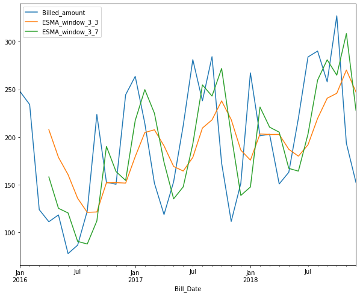

```python
bill_2018[["Billed_amount","ESMA_window_3_3","ESMA_window_3_7"]].plot()
```

# Calculated RMSE value

```python
RMSE_MA_rolling_3=((bill_2018['Billed_amount']-bill_2018["MA_rolling_3"])**2).mean()**0.5
RMSE_W_MA_rolling_3=((bill_2018['Billed_amount']-bill_2018["W_MA_rolling_3"])**2).mean()**0.5
RMSE_EMA_window_3=((bill_2018['Billed_amount']-bill_2018["EMA_window_3"])**2).mean()**0.5
RMSE_ESMA_window_3_7=((bill_2018['Billed_amount']-bill_2018["ESMA_window_3_7"])**2).mean()**0.5
```

```python
RMSE_MA_rolling_3
```

```
61.26408398853503
```

```python
RMSE_W_MA_rolling_3
```

```
65.82572602256133
```

```python
RMSE_EMA_window_3
```

```
64.32131239414655
```

```python
RMSE_ESMA_window_3_7
```

[output not shown]